# Relación entre las horas de sueño, el uso de Inteligencia Artificial y el rendimiento académico

Estudiantes de Estadística y Probabilidades 1 · Sección 1 Grupo 7 · Ciclo 2026-2

Cristobal Aranda · Pedro Chávez · Joaquín Temoche · Eden Paredes · Néstor de la Cruz

2026-11-06

## Objetivos del estudio

**Objetivo general**

Evaluar la relación entre las horas de sueño, el uso de herramientas de Inteligencia Artificial y el rendimiento académico de los estudiantes de Estadística y Probabilidades 1 (Sección 1, ciclo 2026-2).

## Variables de estudio

Se seleccionaron **8 variables principales** provenientes de tres formularios (Diario, Demográfico y Exámenes) :

| Variable | Tipo | Escala / Valores permitidos |
| --- | --- | --- |
| **Horas de sueño** | Cuantitativa continua | Numérica decimal en $[0, 24]$ horas (ej. `6.5 h`) |
| **Nota de examen** | Cuantitativa continua | Numérica decimal en escala vigesimal $[0, 20]$ (ej. `15.5`) |
| **Consultas a IA** | Cuantitativa discreta | Enteros no negativos (`0, 1, 2...`) |
| **Créditos académicos** | Cuantitativa discreta | Enteros positivos en $[0, 40]$ (ej. `18, 20`) |
| **Nivel de comprensión** | Cualitativa ordinal | *Muy bajo* $<$ *Bajo* $<$ *Moderado* $<$ *Alto* $<$ *Muy alto* |
| **Satisfacción académica** | Cualitativa ordinal | Escala Likert ordenada: `1` $<$ `2` $<$ `3` $<$ `4` $<$ `5` |
| **Uso principal de IA** | Cualitativa nominal | *Resolver ejercicios*, *Resumir*, *Programar*, *Redactar*, *No uso IA*, *Otros* |
| **Sensación post-IA** | Cualitativa nominal | *Confianza*, *Alivio*, *Frustración*, *Indiferencia*, *No usó IA* |

## Limpieza y muestra efectiva

### Proceso de depuración

- **Tipificación estricta:** Conversión de variables numéricas (`Horas`, `Consultas`, `Créditos`, `Nota`) y codificación de factores ordinales y nominales.
- **Estandarización de texto:** Agrupación de respuestas libres en `Uso` mediante expresiones regulares hacia *No uso IA* y *Otros*.
- **Control de duplicados:** Filtrado de registros repetidos por estudiante en una misma fecha (`distinct(Cod, Fecha)`) en el formulario diario.

### Tamaño efectivo de muestra

| Base de datos | Registros válidos |
| --- | --- |
| Formulario Diario | 897 |
| Formulario Demográfico | 47 |
| Formulario Exámenes | 207 |
| **Total Sección 1** | **1151** |
| *Aporte del Grupo 7* | *163* |

## Análisis descriptivo: comportamiento univariado

### Medidas de posición y dispersión

[output not shown]

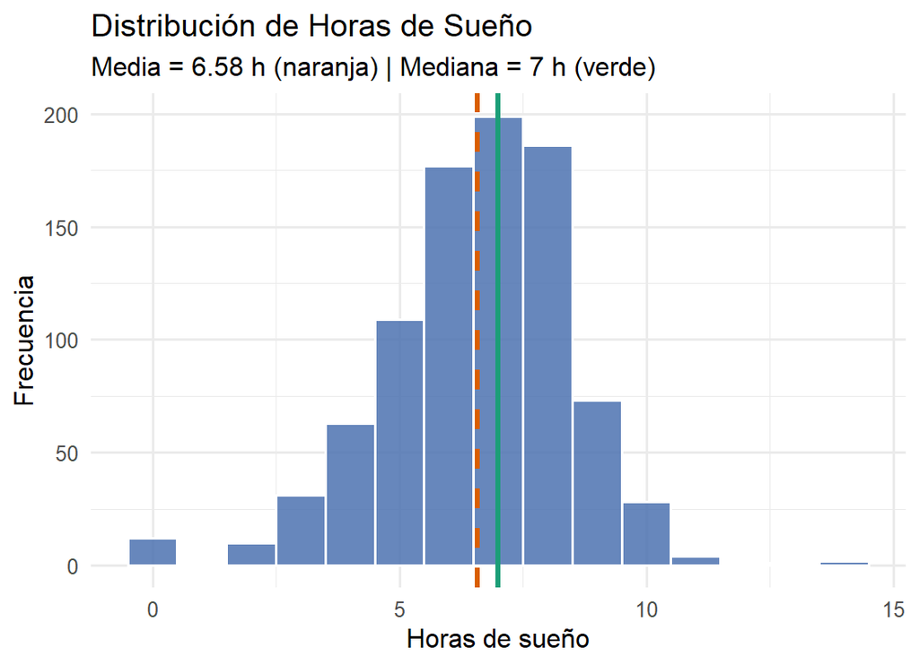

## Análisis descriptivo: interacciones clave

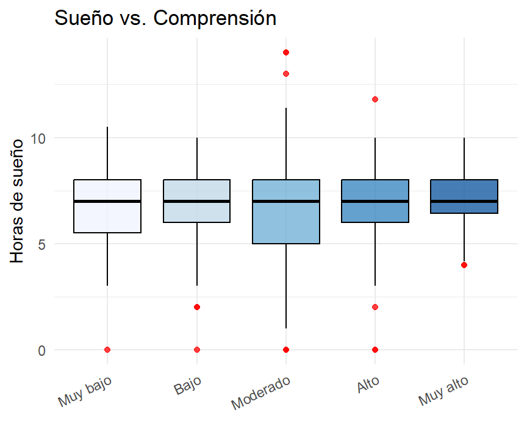

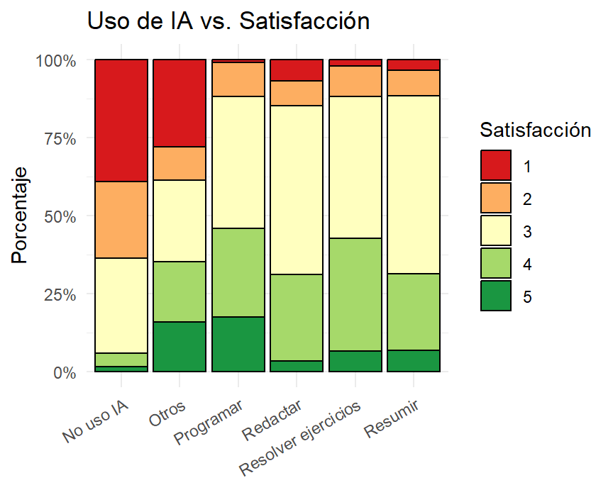

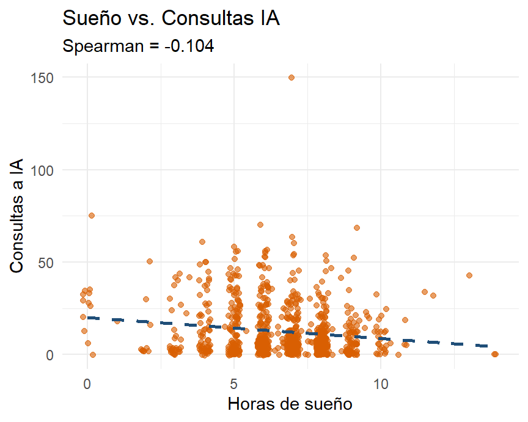

## Probabilidad empírica ($n = 897$)

### Horas de sueño

[output not shown]

### Nivel de comprensión

[output not shown]

**Hallazgo:** Predomina el sueño **Corto (5–7 h)** y los niveles de comprensión **Moderado** y **Alto**.

## Probabilidad condicional e independencia

**Eventos:** $E_1$: dormir $\leq 7$ horas ($P(E_1) = 0.657$) $\;\mid\;$ $E_2$: comprensión *Alto/Muy alto* ($P(E_2) = 0.291$).

### Propiedades y prueba

| Propiedad | Expresión | Valor |
| --- | --- | --- |
| Intersección | $P(E_1 \cap E_2)$ | 0.1806 |
| Producto marginal | $P(E_1) \cdot P(E_2)$ | 0.1911 |
| Unión | $P(E_1 \cup E_2)$ | 0.767 |
| Diferencia simétrica | $P(E_1 \triangle E_2)$ | 0.5864 |
| Desigualdad triangular | $P(E_1 \triangle E_2) \leq P(E_1)+P(E_2)$ | 0.5864 $\leq$ 0.9476 |

### Conclusión de independencia

- **No son independientes:** $P(E_1 \cap E_2) \neq P(E_1)\cdot P(E_2)$ sin redondear.
- **Asociación débil:** La diferencia entre ambas probabilidades es mínima.
- **Desigualdad triangular:** Se cumple satisfactoriamente.

## Teorema de Bayes

Queremos hallar la probabilidad de tener comprensión alta dado que se durmió $\leq 7$ horas: **$P(E_2 \mid E_1)$**.

$$P(E_2 \mid E_1) = \frac{P(E_1 \mid E_2)P(E_2)}{P(E_1 \mid E_2)P(E_2) + P(E_1 \mid E_2^c)P(E_2^c)}$$

| Componente | Valor |
| --- | --- |
| $P(E_1 \mid E_2)$ | 0.6207 |
| $P(E_1 \mid E_2^c)$ | 0.6714 |
| Probabilidad total $P(E_1)$ | 0.6566 |
| **Bayes: $P(E_2 \mid E_1)$** | **0.275 (27.5%)** |

**Interpretación**

Dormir $\leq 7$ h reduce ligeramente la probabilidad de comprensión alta (**27.5%**) frente al promedio general (**29.1%**).

El descanso por sí solo no determina la comprensión académica.

## Variables aleatorias discretas

### 1. Consultas a IA ($X \sim \text{Geom}(p)$)

- **Definición:** Registros hasta encontrar el primero con **$>10$ consultas**.
- **Parámetro:** $p = 0.376$ | $E(X) = 2.66$ | $SD = 2.1$
- **Caso:** $P(X = 20) =$ **0%**

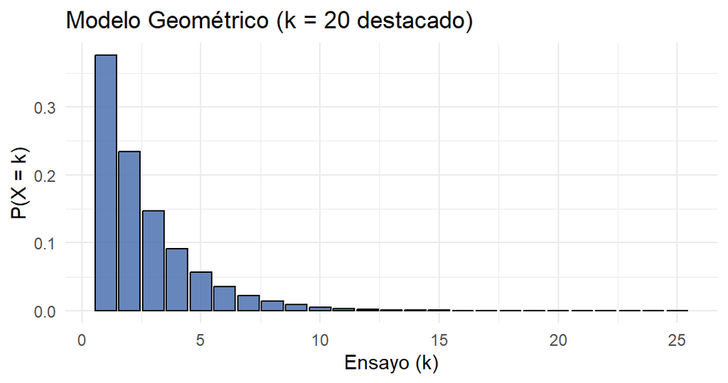

### 2. Créditos ($Y \sim \text{Bin}(10, p)$)

- **Definición:** Registros con **$\geq 20$ créditos** entre 10 elegidos.
- **Parámetro:** $p = 0.447$ | $E(Y) = 4.47$ | $SD = 1.57$
- **Caso:** $P(Y = 7) =$ **7.22%**

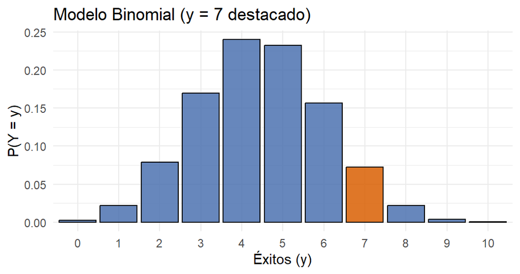

## Variables aleatorias continuas (Aproximación Normal)

### 1. Horas de sueño ($H \sim N(6.58, 3.72)$)

- **Parámetros:** $\mu = 6.58\text{ h}$, $\sigma = 1.93\text{ h}$
- **Validación:** Media y mediana cercanas; ajuste aceptable en zona central.
- **Caso:** $P(6 \leq H \leq 8) =$ **38.73%**

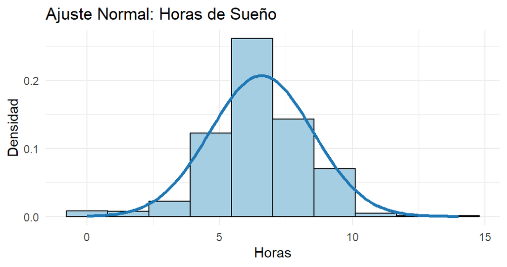

### 2. Nota de examen ($T \sim N(13.32, 20.07)$)

- **Parámetros:** $\mu = 13.32\text{ pts}$, $\sigma = 4.48\text{ pts}$
- **Limitación:** Asigna **6.92%** fuera del rango $[0, 20]$.
- **Caso:** $P(T \geq 14) =$ **43.94%**

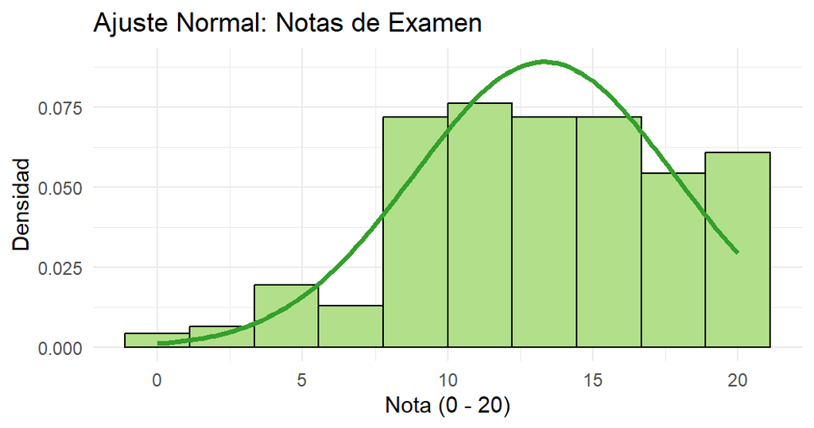

## Conclusiones

1. **Sueño y comprensión:** El descanso diario por sí solo no determina la comprensión académica. La mediana se mantiene en **7 horas** en casi todos los niveles y la diferencia entre $P(E_2 \mid E_1)$ y $P(E_2)$ es mínima.
2. **Uso de IA y satisfacción:** El uso de IA se asocia con mayor satisfacción diaria (destacando **Programar**), mientras que su ausencia concentra mayor insatisfacción. Las consultas intensivas ($>10$) responden a exigencias académicas puntuales y no al cansancio ($\rho \approx 0$).
3. **Modelado probabilístico y alcance:** Los modelos discretos y normales permiten estimar escenarios clave (como **38.73%** de probabilidad de dormir 6–8 h o **43.94%** de obtener nota $\geq 14$). Al ser un estudio observacional con registros repetidos por estudiante, los hallazgos reflejan **asociaciones y no causalidad**.